# HW1 K-Nearest Neighbors Algorithm Analysis

Keith G. Williams 800690755

February 08, 2016

# Algorithm Descriptions

## *k*-Nearest Neighbors

For *k*-Nearest Neighbors, each test tuple is iterated over, and its distance to every other training point is checked. Since the training examples are in a numpy array, numpy’s broadcasting feature is utilized to make these distance calculations fast. For $k=1$ only the minimum distance is required, so for 1-NN, the label of the closest tuple is found and appeneded to the `testY` label array. For $k>1$, the minimum distance is not sufficient, so the resulting distance array is sorted, and the first $k$ distances are sliced and labeled. The mode label is applied to the test point (majority vote) and appended to the `testY` label array.  
Since this approach assumes features are represented as tuples in $\mathbb{R}^n$ and euclidean distance is used, less relevant features will be equally weighted with more relevant features and may lead to less accurate results.

## Condensed Nearest Neighbors

To minimize the memory requirements for *k*-NN, a condensed training set can be found such that the decision boundary is approximately the same for the condensed subset as the full training set. The points in the condensed subset are called the prototypes.  
First, pairwise distances are calculated for each $n$-d point in the training set. These distances are stored as an $m \times m$ matrix, where element $[i, j]$ is the distance from point $i$ to point $j$ in the training set. Though all pairwise distances *might* not be necessary to create a condensed set, calculating them up front avoids recalculating the same distance between two arbitrary points multiple times during the choosing process. Second, the condensed subset is seeded with one random prototype from each class in the training set. The indexes for each prototype are stored as members of a boolean array of length $n_{train}$, where $n_i = 1$ if point $i$ is a prototype in the condensed subset. This boolean array can also be used as a mask to slice the euclidean distance matrix to get the distance of every point in the training set to each prototype in the condensed set during the choosing process, and it can be used to slice `trainY` to get the class label for each prototype in the condensed set. Next, the remaining training points are labeled according to 1-NN, where each point gets the label of its nearest prototype. This label is found by retrieving the index $i$ in the sliced euclidean distance matrix where element $[i, j]$ is the minimum value along column $j$. This index $i$ is used to index the label array such that label $i$ is the label of prototype $i$. Finally one pass is made over the remaining training points. The predicted label is compared to the true label, and if they are not equal, the point is added to the prototype set, and each remaining point is relabeled according to 1-NN against the new prototype set.  
A single pass over the training points after initialization is chosen, so that once a point is labeled correctly, it is never checked again. However, this approach is sensitive to the order in which the points are presented. Further, there are very likely redundant points in the condensed subset. If one wanted to remove these redundancies, each point’s utility could be checked by running leave-one-out 1-NN to check if any labels change when each point is removed from the condensed set. The post-pruning approach would require longer training runtimes, but would improve memory requirements for later tests on novel points.

# Experimental Results

## Run Time Analysis

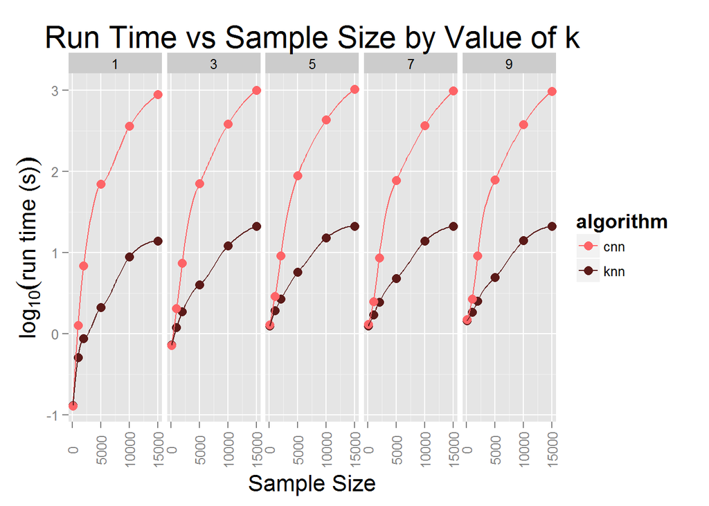

From the above plot, one can see condensed NN is an order of magnitude slower than *k*-NN for the same value of $k$ and $N$. Further, by comparing each value of $k$ for the same $N$, one can see that there is no obvious trend for the effect of $k$ on run time. One important exception is for $k=1$ vs $k>1$. Since the check for nearest neighbors is qualitatively different for $k=1$, a small improvement in run time is observed. Since only the minimum distance value is needed rather than the closest $k$ distances, there is no need to sort neighbor distances for $k=1$.  
To more directly investigate the effect of sample size on run time, the below plots sample size versus run time for each algorithm:

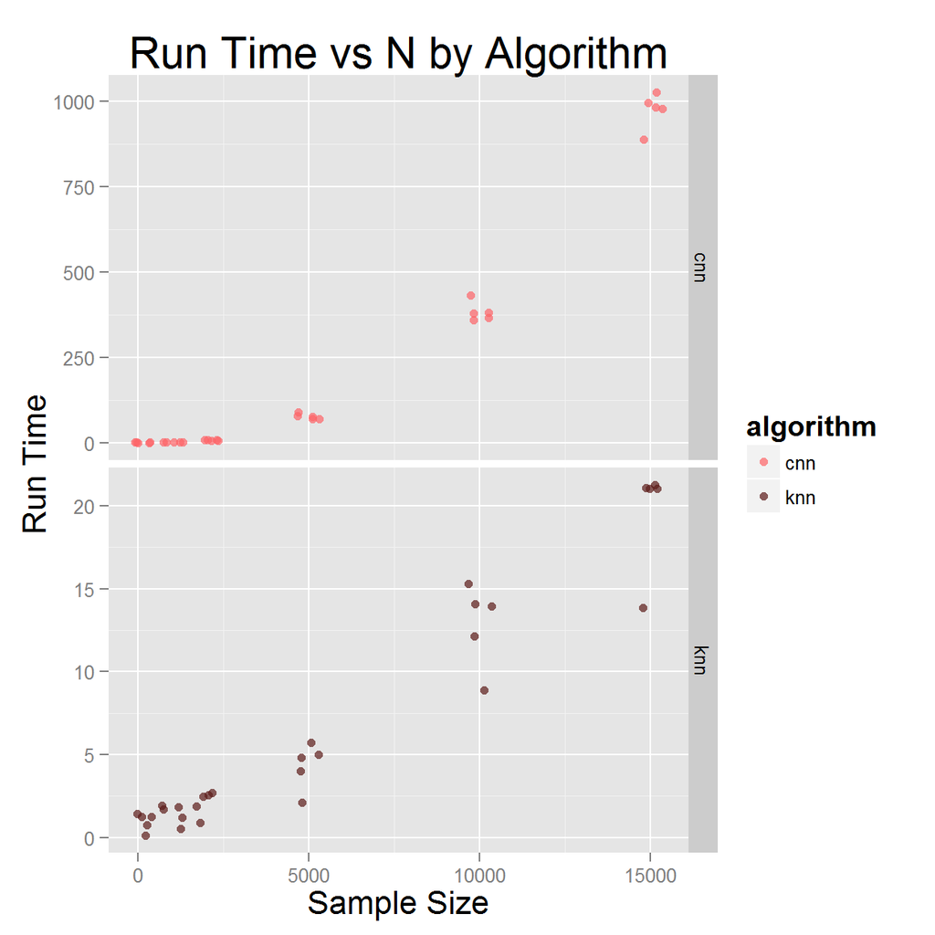

One can also see from this plot that the effect of $k$ is minimal. Additionally, this plot shows condensed NN is quadratic in n, while *k*-NN is sub-quadratic.

## Classification Accuracy

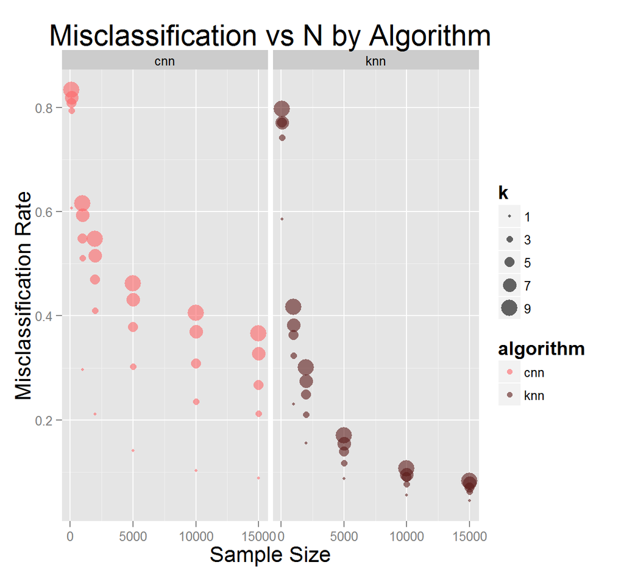

From the above plot, it can be concluded that sample size is the most important factor in classification accuracy; for both algorithms misclassification rate is inversely related to sample size. Further, for each sample size, condensed NN has a much higher misclassification rate. Though, it should be noted that for $k=1$, condensed NN is much more competitive with *k*-NN. Finally, across all sample sizes, for both algorithms, increasing the value of $k$ consistently increases the misclassification rate.

## Confusion Matrix Exemplar

Below is the Confusion Matrix for *k*-NN on 15000 training examples, where $k=5$. The misclassification rate is good at 7%, but a few errors (in the off diagonal) tell an interesting story. It appears the classifier has trouble distinguishing ‘F’ from ‘P’, ‘K’ from ‘X’ and ‘K’ from ‘H’. Given that the symbols for these letters are similar, this makes sense.

|  | A | B | C | D | E | F | G | H | I | J | K | L | M | N | O | P | Q | R | S | T | U | V | W | X | Y | Z |
| --- | --- | --- | --- | --- | --- | --- | --- | --- | --- | --- | --- | --- | --- | --- | --- | --- | --- | --- | --- | --- | --- | --- | --- | --- | --- | --- |
| A | 203 | 0 | 0 | 0 | 0 | 0 | 0 | 0 | 0 | 0 | 1 | 0 | 0 | 0 | 0 | 0 | 0 | 0 | 0 | 0 | 2 | 0 | 0 | 0 | 0 | 0 |
| B | 0 | 160 | 0 | 0 | 0 | 0 | 0 | 1 | 0 | 0 | 0 | 0 | 0 | 1 | 0 | 0 | 0 | 6 | 3 | 0 | 0 | 0 | 0 | 2 | 0 | 0 |
| C | 0 | 0 | 168 | 0 | 1 | 0 | 1 | 0 | 0 | 0 | 0 | 0 | 0 | 0 | 0 | 0 | 1 | 0 | 0 | 0 | 0 | 0 | 0 | 0 | 0 | 0 |
| D | 0 | 4 | 0 | 202 | 0 | 0 | 0 | 7 | 0 | 2 | 0 | 0 | 0 | 0 | 1 | 0 | 0 | 0 | 0 | 0 | 0 | 0 | 0 | 0 | 0 | 0 |
| E | 0 | 1 | 2 | 0 | 165 | 1 | 5 | 0 | 0 | 0 | 4 | 0 | 0 | 0 | 0 | 0 | 0 | 0 | 2 | 0 | 0 | 0 | 0 | 2 | 0 | 9 |
| F | 0 | 1 | 1 | 0 | 1 | 175 | 0 | 1 | 0 | 0 | 0 | 0 | 0 | 2 | 0 | 11 | 0 | 0 | 0 | 0 | 0 | 1 | 0 | 0 | 1 | 0 |
| G | 0 | 1 | 3 | 2 | 3 | 1 | 187 | 2 | 0 | 0 | 1 | 1 | 2 | 0 | 2 | 0 | 3 | 0 | 0 | 0 | 0 | 0 | 0 | 0 | 0 | 0 |
| H | 0 | 3 | 0 | 6 | 4 | 0 | 3 | 143 | 0 | 0 | 7 | 0 | 1 | 0 | 3 | 0 | 2 | 5 | 0 | 0 | 0 | 0 | 0 | 0 | 1 | 0 |
| I | 0 | 1 | 0 | 1 | 0 | 2 | 0 | 0 | 193 | 7 | 0 | 0 | 0 | 1 | 0 | 0 | 0 | 0 | 0 | 0 | 0 | 0 | 0 | 0 | 0 | 0 |
| J | 0 | 0 | 0 | 0 | 1 | 0 | 0 | 0 | 5 | 174 | 0 | 0 | 0 | 0 | 0 | 0 | 2 | 0 | 0 | 0 | 1 | 0 | 0 | 0 | 0 | 0 |
| K | 0 | 2 | 0 | 1 | 2 | 0 | 1 | 14 | 0 | 0 | 148 | 0 | 0 | 0 | 0 | 0 | 0 | 1 | 0 | 0 | 0 | 0 | 1 | 7 | 0 | 0 |
| L | 0 | 0 | 0 | 0 | 0 | 0 | 1 | 1 | 0 | 1 | 1 | 197 | 0 | 0 | 0 | 1 | 0 | 1 | 0 | 0 | 0 | 0 | 0 | 2 | 0 | 0 |
| M | 0 | 3 | 0 | 0 | 0 | 0 | 1 | 0 | 0 | 0 | 0 | 0 | 182 | 0 | 0 | 0 | 0 | 0 | 0 | 0 | 0 | 0 | 1 | 0 | 0 | 0 |
| N | 1 | 1 | 0 | 2 | 0 | 0 | 0 | 2 | 0 | 0 | 1 | 0 | 3 | 179 | 1 | 0 | 0 | 5 | 0 | 0 | 0 | 3 | 0 | 0 | 0 | 0 |
| O | 0 | 1 | 1 | 2 | 0 | 1 | 0 | 0 | 0 | 0 | 0 | 0 | 0 | 2 | 167 | 0 | 6 | 0 | 0 | 0 | 0 | 0 | 1 | 0 | 0 | 0 |
| P | 1 | 1 | 0 | 1 | 0 | 12 | 0 | 3 | 0 | 0 | 0 | 1 | 0 | 0 | 0 | 184 | 2 | 1 | 0 | 0 | 0 | 1 | 0 | 0 | 0 | 0 |
| Q | 0 | 0 | 0 | 1 | 1 | 0 | 3 | 0 | 0 | 0 | 0 | 0 | 0 | 0 | 6 | 1 | 204 | 0 | 0 | 0 | 0 | 0 | 0 | 0 | 1 | 0 |
| R | 0 | 2 | 0 | 5 | 1 | 2 | 0 | 6 | 0 | 0 | 1 | 0 | 0 | 2 | 0 | 1 | 1 | 185 | 0 | 1 | 0 | 1 | 0 | 0 | 0 | 0 |
| S | 0 | 2 | 0 | 0 | 4 | 2 | 0 | 0 | 0 | 0 | 0 | 1 | 0 | 0 | 0 | 0 | 1 | 2 | 184 | 0 | 0 | 0 | 0 | 1 | 0 | 1 |
| T | 0 | 1 | 0 | 3 | 0 | 2 | 0 | 1 | 0 | 0 | 0 | 0 | 0 | 0 | 0 | 0 | 1 | 1 | 0 | 171 | 0 | 1 | 0 | 1 | 2 | 0 |
| U | 0 | 2 | 1 | 0 | 0 | 0 | 0 | 3 | 0 | 0 | 0 | 0 | 0 | 0 | 0 | 0 | 0 | 0 | 0 | 0 | 208 | 1 | 0 | 0 | 0 | 0 |
| V | 0 | 5 | 1 | 0 | 0 | 0 | 1 | 0 | 0 | 0 | 0 | 0 | 0 | 0 | 1 | 0 | 0 | 0 | 0 | 0 | 1 | 159 | 0 | 0 | 0 | 0 |
| W | 0 | 0 | 1 | 0 | 0 | 0 | 0 | 1 | 0 | 0 | 0 | 0 | 2 | 0 | 0 | 0 | 0 | 1 | 0 | 0 | 0 | 0 | 162 | 0 | 0 | 0 |
| X | 1 | 1 | 0 | 1 | 5 | 0 | 0 | 0 | 0 | 1 | 6 | 0 | 0 | 0 | 0 | 0 | 0 | 0 | 0 | 0 | 0 | 0 | 0 | 170 | 0 | 1 |
| Y | 0 | 0 | 0 | 1 | 0 | 0 | 0 | 1 | 0 | 1 | 0 | 0 | 0 | 0 | 0 | 1 | 0 | 0 | 0 | 3 | 0 | 0 | 0 | 1 | 175 | 0 |
| Z | 0 | 0 | 0 | 0 | 0 | 0 | 0 | 0 | 0 | 1 | 0 | 0 | 0 | 0 | 0 | 0 | 2 | 0 | 1 | 0 | 0 | 0 | 0 | 1 | 0 | 189 |

# Appendix

### Figure 1: Experimental Data

| algorithm | k | sample_size | accuracy | run_time |
| --- | --- | --- | --- | --- |
| knn | 1 | 100 | 0.4144667 | 0.1307928 |
| knn | 3 | 100 | 0.2583333 | 0.7292185 |
| knn | 5 | 100 | 0.2290667 | 1.2488839 |
| knn | 7 | 100 | 0.2290667 | 1.2610384 |
| knn | 9 | 100 | 0.2036000 | 1.4479178 |
| cnn | 1 | 100 | 0.3936000 | 0.1288576 |
| cnn | 3 | 100 | 0.2059333 | 0.7170977 |
| cnn | 5 | 100 | 0.1917333 | 1.2970113 |
| cnn | 7 | 100 | 0.1814000 | 1.3117525 |
| cnn | 9 | 100 | 0.1671333 | 1.5044048 |
| knn | 1 | 1000 | 0.7696667 | 0.5119107 |
| knn | 3 | 1000 | 0.6767333 | 1.2067960 |
| knn | 5 | 1000 | 0.6374000 | 1.9201712 |
| knn | 7 | 1000 | 0.6182000 | 1.7210886 |
| knn | 9 | 1000 | 0.5830000 | 1.8373649 |
| cnn | 1 | 1000 | 0.7032000 | 1.2692344 |
| cnn | 3 | 1000 | 0.4891333 | 2.0451665 |
| cnn | 5 | 1000 | 0.4513333 | 2.9106198 |
| cnn | 7 | 1000 | 0.4070667 | 2.4982342 |
| cnn | 9 | 1000 | 0.3842000 | 2.7023353 |
| knn | 1 | 2000 | 0.8439333 | 0.8746457 |
| knn | 3 | 2000 | 0.7893333 | 1.8637551 |
| knn | 5 | 2000 | 0.7508000 | 2.6908534 |
| knn | 7 | 2000 | 0.7252667 | 2.4525257 |
| knn | 9 | 2000 | 0.6990667 | 2.5392322 |
| cnn | 1 | 2000 | 0.7882667 | 6.8980086 |
| cnn | 3 | 2000 | 0.5898000 | 7.4310129 |
| cnn | 5 | 2000 | 0.5306667 | 9.1844432 |
| cnn | 7 | 2000 | 0.4846667 | 8.6263285 |
| cnn | 9 | 2000 | 0.4530000 | 9.1075020 |
| knn | 1 | 5000 | 0.9124667 | 2.1074052 |
| knn | 3 | 5000 | 0.8826667 | 4.0118147 |
| knn | 5 | 5000 | 0.8602000 | 5.7141940 |
| knn | 7 | 5000 | 0.8450000 | 4.8391042 |
| knn | 9 | 5000 | 0.8302667 | 4.9839498 |
| cnn | 1 | 5000 | 0.8587333 | 69.8826424 |
| cnn | 3 | 5000 | 0.6977333 | 70.9902930 |
| cnn | 5 | 5000 | 0.6218667 | 88.8768771 |
| cnn | 7 | 5000 | 0.5692000 | 77.2234150 |
| cnn | 9 | 5000 | 0.5382000 | 78.8709295 |
| knn | 1 | 10000 | 0.9441333 | 8.8740223 |
| knn | 3 | 10000 | 0.9226000 | 12.1150699 |
| knn | 5 | 10000 | 0.9094000 | 15.2938325 |
| knn | 7 | 10000 | 0.9045333 | 13.9410005 |
| knn | 9 | 10000 | 0.8927333 | 14.0818811 |
| cnn | 1 | 10000 | 0.8965333 | 359.5721113 |
| cnn | 3 | 10000 | 0.7647333 | 381.7616871 |
| cnn | 5 | 10000 | 0.6912667 | 432.0180691 |
| cnn | 7 | 10000 | 0.6302000 | 366.8824201 |
| cnn | 9 | 10000 | 0.5947333 | 378.9983289 |
| knn | 1 | 15000 | 0.9547333 | 13.8323979 |
| knn | 3 | 15000 | 0.9371333 | 21.0294983 |
| knn | 5 | 15000 | 0.9295333 | 21.0915528 |
| knn | 7 | 15000 | 0.9214667 | 21.0278783 |
| knn | 9 | 15000 | 0.9173333 | 21.2452001 |
| cnn | 1 | 15000 | 0.9117333 | 888.0537620 |
| cnn | 3 | 15000 | 0.7876000 | 995.0610164 |
| cnn | 5 | 15000 | 0.7330000 | 1024.7707833 |
| cnn | 7 | 15000 | 0.6726000 | 981.9318193 |
| cnn | 9 | 15000 | 0.6343333 | 976.5080718 |

### Figure 2: Python Script for Generating Data

The python script for generating the data is included below. Included are the two main functions tested: `testknn(...)` and `condenseData(...)`. One helper function is used to calculate distances within `testknn`: `euclidean_dist(...)`.

```r
# imports
import numpy as np              # for arrays and math
import pandas as pd             # for importing/exporting csv in tidy format
from scipy.stats import mode   # for fast mode implementation
from scipy.spatial.distance import pdist, squareform  # for pairwise distances
from time import clock          # for timer function
import gc                        # for uninterrupted timing

# constants
DATA_FILE = './letter-recognition.data' # should be in same directory as hw1.py
TRAIN_PROPORTION = 0.75 # proportion of data used to train classifier

#################################################################################
##    Helper Code for Required Functions
#################################################################################

def euclidean_dist(X, y):
    """Returns the distances between all n-dimensional vectors in X
    and n-dimensional vector y.
    inputs:
        x: m*n numpy array
        y: n-dimensional numpy array
    output:
        m-dimensional array of distances between vectors in X and vector y
    """
    return np.sqrt(np.sum((X - y) ** 2, 1)) # broadcasted calculations

#################################################################################
##    Required Functions: testknn(), condenseData()
#################################################################################

def testknn(trainX, trainY, testX, k=1):
    """implementation of k-NN
    inputs:
        trainX: n * D numpy array of training tuples
        trainY: n * 1 numpy array of training labels
        testX: n_test * D numpy array of test tuples
    returns:
        n_test * 1 numpy array of test labels
    """
    nTest = testX.shape[0]
    testY = []

    # iterate over test tuples
    for i in xrange(nTest):
        # compute distances to every point in trainX
        distances = euclidean_dist(trainX, testX[i])

        # assign label based on minimum distance(s)
        if k == 1:
            label = trainY[np.argmin(distances)] # optimized for k=1

        # for k > 1
        else:
            k_shortest_distances = np.sort(distances)[:k]
            nn_labels = [trainY[np.where(distances == distance)[0][0]] for distance in k_shortest_distances]
            label = mode(nn_labels)[0][0]       # assign label by majority vote

        testY.append(label)

    return np.array(testY)

def condenseData(trainX, trainY):
    """Finds a consistent subset of the training data whose 1-NN decision
        boundary correctly classifies all training data.
        inputs:
            trainX: n * D numpy array of training tuples
            trainY: n * 1 numpy array of training labels
        returns:
            numpy array of indices of consistent subset of training data
    """
    # get euclidean distance matrix
    edm = squareform(pdist(trainX))

    # initialize prototype subset
    ntrain = trainX.shape[0]
    classes = np.unique(trainY)
    condensedIdx = np.zeros(ntrain).astype(bool)

    for cls in classes:
        mask = trainY == cls
        rep = np.random.randint(0, np.sum(mask))
        condensedIdx[np.where(mask)[0][rep]] = True

    # slice edm to include only prototype subset
    edm_p = edm[condensedIdx]

    # label remaining points using 1-NN
    labels_t = trainY[condensedIdx]
    labels_h = labels_t[np.argmin(edm_p, 0)]

    # iterate over remaining points
    for i in range(ntrain):
        # if point is misclassified, add to prototype subset
        if labels_h[i] != trainY[i]:
            condensedIdx[i] = True
            edm_p = edm[condensedIdx]
            labels_t = trainY[condensedIdx]
            labels_h = labels_t[np.argmin(edm_p, 0)] # 1-NN w/new prototype

    return np.where(condensedIdx)[0]

#################################################################################
##    Code for Running Required 60 Experiments
#################################################################################

def timer(trainX, trainY, testX, k, condensed=False):
    """timer function for comparing running times of NN algorithms.
    Returns a tuple of run-time and predicted labels"""

    gc.disable() # disable garbage collector for uninterrupted timing
    initial = clock()
    if condensed:
        cnn = condenseData(trainX, trainY)
        testY = testknn(trainX[cnn], trainY[cnn], testX, k)
    else:
        testY = testknn(trainX, trainY, testX, k)
    final = clock()

    gc.enable() # turn garbage collector back on
    return ((final - initial), testY)

def confusion_matrix(predictions, truth):
    """computes confusion matrix
    Input:
        predictions: array of predicted labels
        truth: array of known labels, aligned with predictions
    Output:
        c * c pandas dataframe, where c is the number of classes in labels"""
    # get class labels
    classes = np.unique(truth) # sorted

    # create an index for class labels
    class_index = dict((idx, cls) for cls, idx in enumerate(classes))

    # convert predictions and truth labels to indices
    pred_to_index = np.array([class_index[label] for label in predictions])
    truth_to_index = np.array([class_index[label] for label in truth])

    # create confusion matrix
    cmx = np.zeros((classes.size, classes.size))
    for i in xrange(truth.size):
        cmx[truth_to_index[i], pred_to_index[i]] += 1

    # return pandas dataframe where i -> truth, j -> prediction
    return pd.DataFrame(cmx, index=classes, columns=classes)

def accuracy(confusion_matrix):
    """computes accuracy given a confusion matrix
    Input:
        confusion_matrix as c * c numpy array, where c is the number of classes
    Output:
        float accuracy = N_correct / N"""
    return confusion_matrix.diagonal().sum() / confusion_matrix.sum()

def results_to_df(ary, ks, ns):
    """converts 4-d array of experimental results
    into a pandas data frame for easy storage and analysis.
    Inputs:
        ary: 4d numpy array of experimental results
        ks: list of k values used for experiments
        ns: list of sample sizes used for experiments
    Output:
        n * 5 pandas data frame, where n is the number of experiments run"""

    # create columns as dictionaries
    results = {}
    results['algorithm'] = ['knn' for i in range(ary.size / 4)] + ['cnn' for j in range(ary.size / 4)]
    results['sample_size'] = ns * (2 * len(ks))
    k = []
    for ii in range(len(ks)):
        k += [ks[ii] for jj in range(len(ns))]
    results['k'] = k + k
    results['run_time'] = ary[0].reshape(60)
    results['accuracy'] = ary[1].reshape(60)

    return pd.DataFrame(results)

def run_experiments():
    # read-in data file
    df = pd.read_csv(DATA_FILE, header=None)

    # split data into train and test
    nTrain = int(TRAIN_PROPORTION * len(df))

    trainX = df.values[:nTrain, 1:].astype(float)
    trainY = df.values[:nTrain, 0].astype(str)
    testX = df.values[nTrain:, 1:].astype(float)
    test_labels = df.values[nTrain:, 0].astype(str)

    """4D matrix for storing results (i, j, k, n)
    i: {0: runtime, 1: accuracy}
    j: {0: knn, 1: cnn}
    k: value of k in {1, 3, 5, 7, 9}
    n: sample size in {100, 1e3, 2e3, 5e3, 1e4, 1.5e4}"""
    k_vals = [1, 3, 5, 7, 9]
    sample_sizes = [100, 1000, 2000, 5000, 10000, 15000]
    times_accuracies = np.zeros((2, 2, 5, 6))

    # run experiments, collect runtime and accuracy
    for k in range(len(k_vals)):
        for n in range(len(sample_sizes)):
            sample_indices = np.random.choice(len(trainX), sample_sizes[n], replace=False)
            for j in range(2):
                if j == 0:
                    cnn = False # flag for condensed 1-NN algorithm
                else:
                    cnn = True
                result = timer(trainX[sample_indices], trainY[sample_indices], testX, k_vals[k], condensed=cnn)
                cm = confusion_matrix(result[1], test_labels)
                times_accuracies[0, j, k, n] = result[0]
                times_accuracies[1, j, k, n] = accuracy(cm.values)

                # progress check
                print 'k:', k_vals[k], ' n: {:5d}'.format(sample_sizes[n]), \
                ' CNN: {:6}'.format(str(cnn)), \
                '{:02d}:{:06.3f}'.format(int(result[0] // 60), result[0] % 60)

    # export results data to csv
    RUN = 6
    dat = results_to_df(times_accuracies, k_vals, sample_sizes)
    dat.to_csv('hw1-results-run{}.csv'.format(RUN), index=False)

if __name__ == "__main__":
    run_experiments()
```